# SEACAR Coral Analysis: Percent Cover

Last compiled on 05 August, 2026

# Important Notes

The purpose of this script is to create managed area statistics, perform linear mixed effect analysis, generate summary plots, and create reports in pdf and Word document form for Coral percent cover.

These scripts were created by J.E. Panzik (jepanzik@usf.edu) for SEACAR. Updated by T.G. Hill (Tyler.Hill@FloridaDEP.gov).

All scripts and outputs can be found on the SEACAR GitHub repository:

https://github.com/FloridaSEACAR/SEACAR_Trend_Analyses

This markdown file is designed to be compiled by Coral_Plot_Render.R (https://github.com/FloridaSEACAR/SEACAR_Trend_Analyses/blob/main/Coral/Coral_Plot_Render.R).

# Coral Percent Cover

## Biscayne Bay-Cape Florida to Monroe County Line Aquatic Preserve

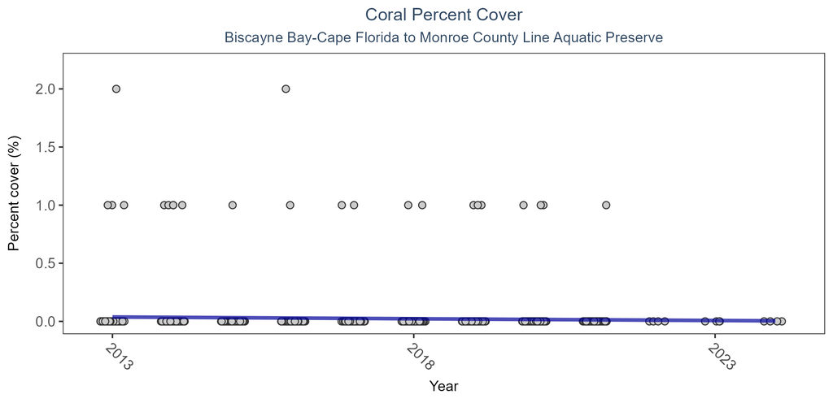

Coral Percent Cover - Biscayne Bay-Cape Florida to Monroe County Line Aquatic Preserve

| Statistical Trend | Period of Record | LME Intercept | LME Slope | p |
| --- | --- | --- | --- | --- |
| No detectable trend | 2013 - 2024 | 6.1 | 0 | 0.14 |

Percent cover showed no detectable trend between 2013 and 2024.

[figure not shown]

## Coupon Bight Aquatic Preserve

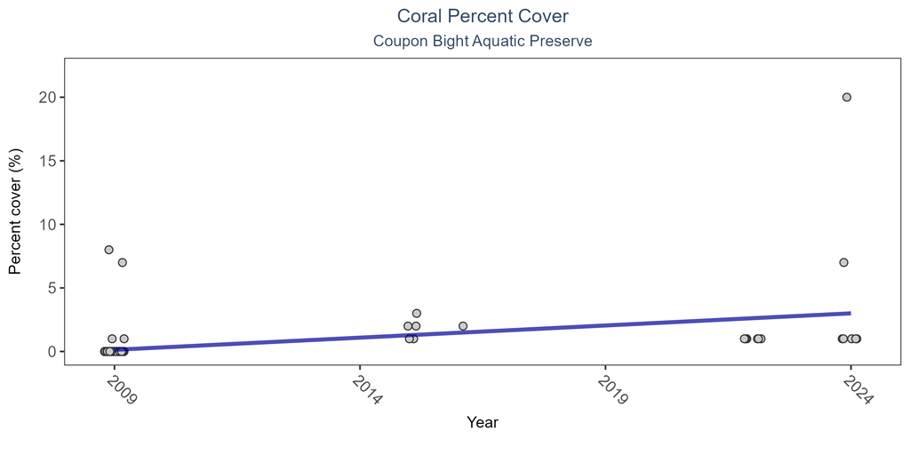

Coral Percent Cover - Coupon Bight Aquatic Preserve

| Statistical Trend | Period of Record | LME Intercept | LME Slope | p |
| --- | --- | --- | --- | --- |
| No detectable trend | 2009 - 2024 | -383.85 | 0.19 | 0.17 |

Percent cover showed no detectable trend between 2009 and 2024.

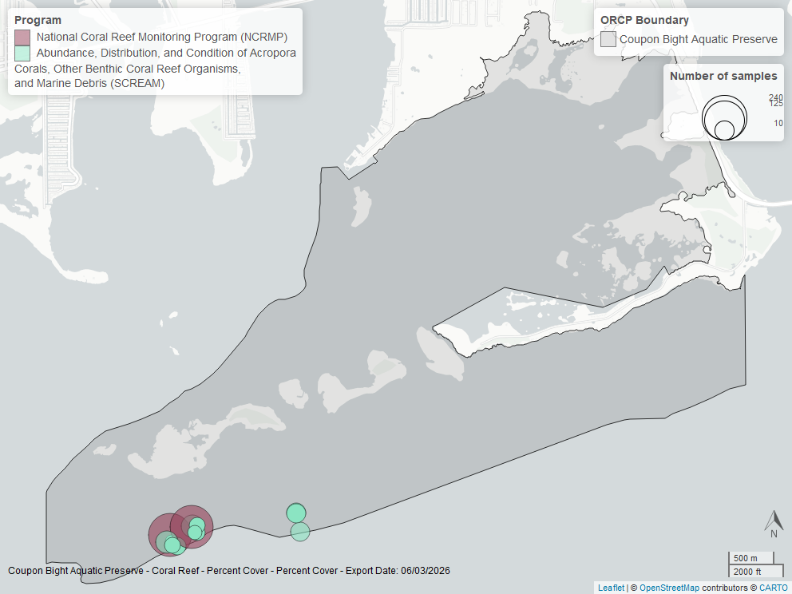

## Florida Keys National Marine Sanctuary

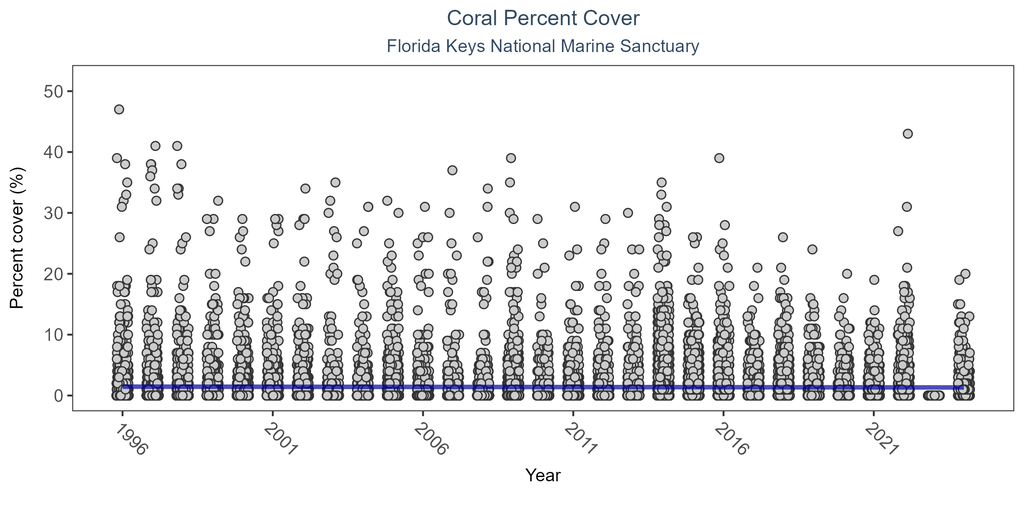

Coral Percent Cover - Florida Keys National Marine Sanctuary

| Statistical Trend | Period of Record | LME Intercept | LME Slope | p |
| --- | --- | --- | --- | --- |
| Decreasing trend | 1996 - 2024 | 11.02 | 0 | 0 |

Annual average percent cover decreased by less than 0.01% between 1996 and 2024.

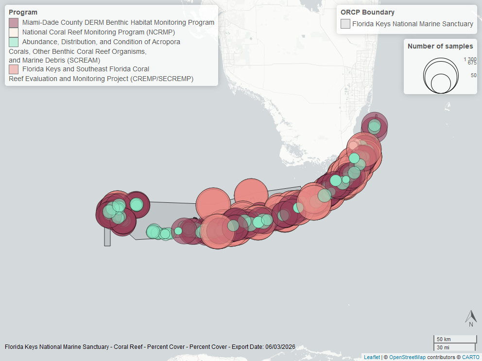

## Kristin Jacobs Coral Aquatic Preserve

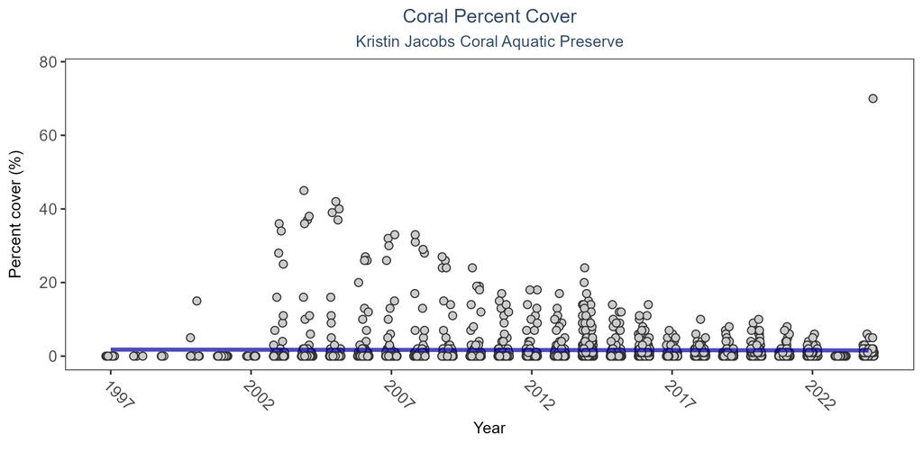

Coral Percent Cover - Kristin Jacobs Coral Aquatic Preserve

| Statistical Trend | Period of Record | LME Intercept | LME Slope | p |
| --- | --- | --- | --- | --- |
| Decreasing trend | 1997 - 2024 | 18.13 | -0.01 | 0 |

Annual average percent cover decreased by 0.01% between 1997 and 2024.

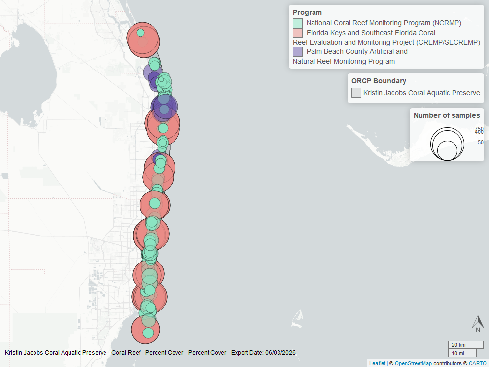

# Libraries and Settings

Loads libraries used in the script. The inclusion of `scipen` option limits how frequently R defaults to scientific notation. Sets default settings for displaying warning and messages in created document, and sets figure dpi.

```r
library(knitr)
library(data.table)
library(dplyr)
library(lubridate)
library(ggplot2)
library(scales)
library(tidyr)
library(gridExtra)
#library(tidyverse)
library(nlme)
library(ggpubr)
options(scipen=999)
knitr::opts_chunk$set(
   warning=FALSE,
   message=FALSE,
   dpi=200
)
seed <- 42
```

# File Import

Imports file that is determined in the Coral_PC_ReportRender.R script.

The command `fread` is used because of its improved speed while handling large data files. Only columns that are used by the script are imported from the file, and are designated in the `select` input.

The script then gets the name of the parameter as it appears in the data file and units of the parameter.

The latest version of Coral data is available at: https://usf.box.com/s/8hyj2ur5arothlifg1isnq2gxisjzbdg

The file(s) being used for the analysis: **All_CORAL_Parameters-2026-Jun-04.txt**

```r
data <- fread(file_in, sep="|", header=TRUE, stringsAsFactors=FALSE,
              na.strings=c("NULL","","NA"))

cat(paste("The data file(s) used:", file_short, sep="\n"))
```

# Data Filtering

The processing and filtering that is done to the data is as follows:

```r
# Only keep data for Percent Cover
# Formerly "Percent Cover - Species Composition"
data <- data[ParameterName=="Percent Cover", ]

# Sets units for percent cover
unit <- "%"
data$ParameterUnits <- unit

# Remove any rows that are not corals
data <- data[SpeciesGroup1 %in% c("Octocoral","Milleporans","Scleractinian"), ]
# Remove rows with missing GenusName
data <- data[!is.na(data$GenusName),]
# Remove rows with missing SpeciesName
data <- data[!is.na(data$SpeciesName),]
# Remove rows with missing Months
data <- data[!is.na(data$Month),]
# Remove rows with missing Years
data <- data[!is.na(data$Year),]
# Remove rows with missing SpeciesGroup1
data <- data[!is.na(data$SpeciesGroup1),]
# Remove rows with missing ResultValue
data <- data[!is.na(data$ResultValue),]
# Remove rows with missing SampleDate
data <- data[!is.na(data$SampleDate),]
# Remove duplicate rows
data <- data[data$MADup==1,]
# Create variable that combines the genus and species name
data$gensp <- paste(data$GenusName, data$SpeciesName, sep=" ")
```

# Managed Area Statistics

```r
# Create summary statistics for each managed area based on Year and Month
# intervals.
MA_YM_Stats <- data %>%
  group_by(AreaID, ManagedAreaName, Year, Month) %>%
  summarize(ParameterName=parameter,
            N_Data=length(na.omit(ResultValue)),
            Min=min(ResultValue),
            Max=max(ResultValue),
            Median=median(ResultValue),
            Mean=mean(ResultValue),
            StandardDeviation=sd(ResultValue),
            Programs=paste(sort(unique(ProgramName), decreasing=FALSE),
                           collapse=', '),
            ProgramIDs=paste(sort(unique(ProgramID), decreasing=FALSE),
                             collapse=', '),
            .groups = "keep")
# Puts the data in order based on ManagedAreaName, Year, then Month
MA_YM_Stats <- as.data.table(MA_YM_Stats[order(MA_YM_Stats$ManagedAreaName,
                                               MA_YM_Stats$Year,
                                               MA_YM_Stats$Month), ])
# Writes summary statistics to file
fwrite(MA_YM_Stats, paste0(out_dir,"/Coral_", param_file,
                           "_MA_MMYY_Stats.txt"), sep="|")
# Removes variable storing data to improve computer memory
rm(MA_YM_Stats)

# Create summary statistics for each managed area based on Year intervals
MA_Y_Stats <- data %>%
  group_by(AreaID, ManagedAreaName, Year) %>%
  summarize(ParameterName=parameter,
            N_Data=length(na.omit(ResultValue)),
            Min=min(ResultValue),
            Max=max(ResultValue),
            Median=median(ResultValue),
            Mean=mean(ResultValue),
            StandardDeviation=sd(ResultValue),
            Programs=paste(sort(unique(ProgramName), decreasing=FALSE),
                           collapse=', '),
            ProgramIDs=paste(sort(unique(ProgramID), decreasing=FALSE),
                             collapse=', '),
            .groups = "keep")
# Puts the data in order based on ManagedAreaName then Year
MA_Y_Stats <- as.data.table(MA_Y_Stats[order(MA_Y_Stats$ManagedAreaName,
                                             MA_Y_Stats$Year), ])
# Writes summary statistics to file
fwrite(MA_Y_Stats, paste0(out_dir,"/Coral_", param_file,
                          "_MA_Yr_Stats.txt"), sep="|")

# Create summary statistics for each managed area based on Month intervals.
MA_M_Stats <- data %>%
  group_by(AreaID, ManagedAreaName, Month) %>%
  summarize(ParameterName=parameter,
            N_Data=length(na.omit(ResultValue)),
            Min=min(ResultValue),
            Max=max(ResultValue),
            Median=median(ResultValue),
            Mean=mean(ResultValue),
            StandardDeviation=sd(ResultValue),
            Programs=paste(sort(unique(ProgramName), decreasing=FALSE),
                           collapse=', '),
            ProgramIDs=paste(sort(unique(ProgramID), decreasing=FALSE),
                             collapse=', '),
            .groups = "keep")
# Puts the data in order based on ManagedAreaName then Month
MA_M_Stats <- as.data.table(MA_M_Stats[order(MA_M_Stats$ManagedAreaName,
                                             MA_M_Stats$Month), ])
# Writes summary statistics to file
fwrite(MA_M_Stats, paste0(out_dir,"/Coral_", param_file,
                          "_MA_Mo_Stats.txt"), sep="|")
# Removes variable storing data to improve computer memory
rm(MA_M_Stats)

# Create summary overall statistics for each managed area.
MA_Ov_Stats <- data %>%
  group_by(AreaID, ManagedAreaName) %>%
  summarize(ParameterName=parameter,
            N_Years=length(unique(na.omit(Year))),
            SufficientData=ifelse(N_Years>=5, TRUE, FALSE),
            EarliestYear=min(Year),
            LatestYear=max(Year),
            N_Data=length(na.omit(ResultValue)),
            Min=min(ResultValue),
            Max=max(ResultValue),
            Median=median(ResultValue),
            Mean=mean(ResultValue),
            StandardDeviation=sd(ResultValue),
            Programs=paste(sort(unique(ProgramName), decreasing=FALSE),
                           collapse=', '),
            ProgramIDs=paste(sort(unique(ProgramID), decreasing=FALSE),
                             collapse=', '),
            .groups = "keep")
# Puts the data in order based on ManagedAreaName
MA_Ov_Stats <- as.data.table(MA_Ov_Stats[order(MA_Ov_Stats$ManagedAreaName), ])

# Replaces blank ProgramIDs with NA (missing values)
MA_Ov_Stats$ProgramIDs <- replace(MA_Ov_Stats$ProgramIDs,
                                  MA_Ov_Stats$ProgramIDs=="", NA)
MA_Ov_Stats$Programs <- replace(MA_Ov_Stats$Programs,
                                MA_Ov_Stats$Programs=="", NA)
# Write overall statistics to file
fwrite(MA_Ov_Stats, paste0(out_dir,"/Coral_", param_file,
                           "_MA_Overall_Stats.txt"), sep="|")
# Creates a variable with the names of all the managed areas that contain
# species observations
coral_pc_MA_Include <- MA_Ov_Stats[!is.na(Mean) & SufficientData==TRUE, unique(ManagedAreaName)]

# Puts the managed areas in alphabetical order
coral_pc_MA_Include <- coral_pc_MA_Include[order(coral_pc_MA_Include)]

# Determines the number of managed areas used
n <- length(coral_pc_MA_Include)
```

# Linear Mixed Effects Models

Performs a linear mixed effects (LME) model on each managed area between using a relationship between percent cover and year.

The following steps are performed:

1. Create a blank data frame to store results
2. Sets the column names for the data to be stored from LME model
3. Starts a loop for each managed area included in the analysis
4. Gets data for the current managed area
5. Performs LME on current managed area
6. Stores information and fits into lme_stats data frame for current managed area
7. Merges lme_stats with MA_Ov_Stats to create a data frame with gegneral statistics and the LME parameters
8. Puts lme_stats in alphabetical order by managed area name
9. Write lme_stats to a pipe-delimited .txt file in the output directory
   - [Coral Percent Cover Output Files in SEACAR GitHub](https://github.com/FloridaSEACAR/SEACAR_Trend_Analyses/tree/main/Coral/output/PercentCover) (https://github.com/FloridaSEACAR/SEACAR_Trend_Analyses/tree/main/Coral/output/PercentCover)
10. Gets the start and endpoints for LME fit to be used in plots.

```r
# Creates blank data frame with number of rows defined by how many managed areas
# are going to be analyzed
lme_stats <- data.frame(matrix(ncol = 5, nrow = n))
# Sets column names for blank data frame
colnames(lme_stats) <- c("AreaID", "ManagedAreaName", "LME_Intercept",
                         "LME_Slope", "LME_p")

# Begins to loop through each managed area for analysis
for(i in 1:n){
  ma_i <- coral_pc_MA_Include[i]
  # Gets data for current managegd area
  lme_data <- data[ManagedAreaName==ma_i,]
  # Perform LME for relation between ResultValue and Year for current managed area
  AnyCoral<-lme(ResultValue ~ Year,
                random =~1|ProgramLocationID,
                na.action = na.omit,
                data = lme_data)
  # Store information and model fits in appropriate row of data frame
  lme_stats$AreaID[i] <- unique(lme_data$AreaID)
  lme_stats$ManagedAreaName[i] <- ma_i
  lme_stats$LME_Intercept[i] <- AnyCoral$coefficients$fixed[1]
  lme_stats$LME_Slope[i] <- AnyCoral$coefficients$fixed[2]
  lme_stats$LME_p[i] <- anova(AnyCoral)$p[2]

  # Clears temporary variables for memory
  rm(lme_data)
  (AnyCoral)
}

# Merges LME stats with overall stats to complete stats for each managed area
lme_stats <- merge.data.frame(MA_Ov_Stats[,-c("Programs", "ProgramIDs")],
                              lme_stats, by=c("AreaID", "ManagedAreaName"), all=TRUE)

# Puts the data in order based on ManagedAreaName
lme_stats <- as.data.frame(lme_stats[order(lme_stats$ManagedAreaName), ])

# Write lme statistics to file
fwrite(lme_stats, paste0(out_dir,"/Coral_", param_file,
                         "_LME_Stats.txt"), sep="|")

# Gets lower x and y values based on LME fit to use in plot
lme_plot <- lme_stats %>%
  group_by(AreaID, ManagedAreaName) %>%
  summarize(x=EarliestYear,
            y=LME_Slope*x+LME_Intercept, .groups = "keep")
# Gets upper x and y values based on LME fit to use in plot
lme_plot2 <- lme_stats %>%
  group_by(AreaID, ManagedAreaName) %>%
  summarize(x=LatestYear,
            y=LME_Slope*x+LME_Intercept, .groups = "keep")
# Merges LME fit values for plot into one data frame
lme_plot <- bind_rows(lme_plot, lme_plot2)
rm(lme_plot2)
# Puts LME plot data fram in alphabetical order by managed area
lme_plot <- as.data.frame(lme_plot[order(lme_plot$ManagedAreaName), ])
lme_plot <- lme_plot[!is.na(lme_plot$y),]
```

# Appendix I: Plots

1. Set common plot theme.
2. Starts a loops that creates plots for each managed area analyzed
3. Determine the earliest and latest year of the data to create x-axis scale and intervals
4. Determine the upper and lower limit of the plot for better y-axis labels
5. Set the plot type as a jitter plot with the size of the points to show concentration of data
6. Add LME trendline
7. Create the title, x-axis, y-axis
8. Set the y and x limits
9. Apply common plot theme
10. Add table with summary statistics below each figure
    - Numerical non-integer values are rounded to 2 decimal places
    - StandardDeviation is renamed StDev for space reasons
11. Create file name to save figure
12. Save figure as png file
- [Coral Percent Cover Figures in SEACAR GitHub](https://github.com/FloridaSEACAR/SEACAR_Trend_Analyses/tree/main/Coral/output/PercentCover/Figures) (https://github.com/FloridaSEACAR/SEACAR_Trend_Analyses/tree/main/Coral/output/PercentCover/Figures)

```r
# Defines standard plot theme: black and white, no major or minor grid lines,
# Arial font. Title is centered, size 12, and blue (hex coded). Subtitle is
# centered, size 10, and blue (hex coded). Legend title is size 10 and the
# legend is left-justified. X-axis title is size 10 and the margins are padded
# at the top and bottom to give more space for angled axis labels. Y-axis title
# is size 10 and margins are padded on the right side to give more space for
# axis labels. Axis labels are size 10 and the x-axis labels are rotated -45
# degrees with a horizontal justification that aligns them with the tick mark
plot_theme <- theme_bw() +
  theme(panel.grid.major = element_blank(),
        panel.grid.minor = element_blank(),
        text=element_text(family="Arial"),
        plot.title=element_text(hjust=0.5, size=12, color="#314963"),
        plot.subtitle=element_text(hjust=0.5, size=10, color="#314963"),
        legend.title=element_text(size=10),
        legend.text = element_text(hjust=0),
        axis.title.x = element_text(size=10, margin = margin(t = 5, r = 0,
                                                             b = 10, l = 0)),
        axis.title.y = element_text(size=10, margin = margin(t = 0, r = 10,
                                                             b = 0, l = 0)),
        axis.text=element_text(size=10),
        axis.text.x=element_text(angle = -45, hjust = 0))
# Create jitter object that sets the height and width
# Sets seed to be reproducible
plot_jitter <- position_jitter(width = 0.2, height = 0.2, seed=seed)

# Loop that cycles through each managed area with data
if(n==0){
  # Prints a statement if there are no managed areas with appropriate data
  print("There are no locations that qualify.")
} else {
  for (i in 1:n) {
    ma_i <- coral_pc_MA_Include[i]
    # Gets data for target managed area
    plot_data <- data[ManagedAreaName==ma_i,]

    lme_plot_data <- lme_plot[ManagedAreaName==ma_i,]
    # Determines most recent year with available data for managed area
    t_max <- max(MA_Ov_Stats[ManagedAreaName==ma_i, LatestYear])
    # Determines earliest recent year with available data for managed area
    t_min <- min(MA_Ov_Stats[ManagedAreaName==ma_i, EarliestYear])
    # Determines how many years of data are present
    t <- t_max-t_min

    # Creates break intervals for plots based on number of years of data
    if(t>=30){
      # Set breaks to every 10 years if more than 30 years of data
      brk <- -10
    }else if(t<30 & t>=10){
      # Set breaks to every 5 years if between 30 and 10 years of data
      brk <- -5
    }else if(t<10 & t>=4){
      # Set breaks to every 2 years if between 10 and 4 years of data
      brk <- -2
    }else if(t<4 & t>=2){
      # Set breaks to every year if between 4 and 2 years of data
      brk <- -1
    }else if(t<2){
      # Set breaks to every year if less than 2 years of data
      brk <- -1
      # Sets t_max to be 1 year greater and t_min to be 1 year lower
      # Forces graph to have at least 3 tick marks
      t_max <- t_max+1
      t_min <- t_min-1
    }
    # Determine range of data values for the managed area
    y_range <- max(plot_data$ResultValue) - min(plot_data$ResultValue)

    # Sets y_min to be -1
    y_min <- -1

    # Sets upper bound of y-axis to be 10% of the data range above the
    # maximum value.
    y_max <- max(plot_data$ResultValue)+(0.1*y_range)

    # Creates plot object using plot_data.
    # Data is plotted as a point pot with jitter to show concentrations
    # that overlap. LME fit is plotted as a line
    p1 <- ggplot(data=plot_data) +
      geom_point(aes(x=Year, y=ResultValue),
                 position=plot_jitter, shape=21, size=2,
                 color="#333333", fill="#cccccc", alpha=1) +
      geom_line(data=lme_plot_data, aes(x=x, y=y),
                color="#000099", size=2, alpha=0.8) +
      labs(title="Coral Percent Cover",
           subtitle=ma_i,
           x="Year", y="Percent cover (%)") +
      scale_x_continuous(limits=c(t_min-0.25, t_max+0.25),
                         breaks=seq(t_max, t_min, brk)) +
      scale_y_continuous(limits=c(y_min, y_max),
                         breaks=pretty_breaks(n=5)) +
      plot_theme
    # Sets file name of plot created
    outname <- paste0("Coral_", param_file, "_", gsub(" ", "", ma_i),
                      ".png")
    # Saves plot as a png image
    png(paste0(out_dir, "/Figures/", outname),
        width = 8,
        height = 4,
        units = "in",
        res = 200)
    print(p1)
    dev.off()

    # Creates a data table object to be shown underneath plots in report
    ResultTable <- lme_stats[ManagedAreaName==ma_i,]
    # Removes location, and parameter information because it is in plot
    # labels
    ResultTable <- select(ResultTable, -c("AreaID", "ManagedAreaName",
                                          "ParameterName"))
    # Renames StandardDeviation to StDev to save horizontal space
    ResultTable <- ResultTable %>%
      rename("StDev"="StandardDeviation")
    # Converts all non-integer values to 2 decimal places for space
    ResultTable$Min <- round(ResultTable$Min, digits=2)
    ResultTable$Max <- round(ResultTable$Max, digits=2)
    ResultTable$Median <- round(ResultTable$Median, digits=2)
    ResultTable$Mean <- round(ResultTable$Mean, digits=2)
    ResultTable$StDev <- round(ResultTable$StDev, digits=2)
    ResultTable$LME_Intercept <- round(ResultTable$LME_Intercept, digits=2)
    ResultTable$LME_Slope <- round(ResultTable$LME_Slope, digits=2)
    ResultTable$LME_p <- round(ResultTable$LME_p, digits=4)
    # Stores as plot table object
    t1 <- ggtexttable(ResultTable, rows = NULL,
                      theme=ttheme(base_size=7)) %>%
      tab_add_footnote(text="LME_p < 0.00005 appear as 0 due to rounding.",
                       size=10, face="italic")
    # Combines plot and table into one figure
    print(ggarrange(p1, t1, ncol=1, heights=c(0.85, 0.15)))

    # Add extra space at the end to prevent the next figure from being too
    # close. Does not add space after last plot
    if(i!=n){
      cat("\n \n \n \n")
    }
  }
}
```

[output not shown]